# PCA vs MFA

Antonio Miñarro (aminarro@ub.edu)

12 març, 2025

# Càlcul d’un MFA

En aquest document realitzem amb les eines bàsiques de R un MFA sobre un conjunt de dades simulades per entendre les diferències i similituds amb un PCA.

Simulem un data frame amb 5 variables dividides en dos grups: un grup amb 3 variables i un grup amb 2 variables.

Simulem un total de 10 individus.

## Simulació de les dades

Un cop simulades centrem i escalem les dades per tal de que tinguin mitjana 0 i desviació típica 1.

```r
set.seed(1235)
n<-10
X1<-round(rnorm(n,10,1),2)
X2<-round(rnorm(n,20,2),2)
X3<-round(2*X1+rnorm(n,0,0.2),2)
Y1<-round(rnorm(n,5,1),2)
Y2<-round(rnorm(n,3,0.5),2)
dades<-data.frame(X1,X2,X3,Y1,Y2)
summary(dades)
```

```
##        X1              X2              X3              Y1
##  Min.   : 8.72   Min.   :18.12   Min.   :17.04   Min.   :2.500
##  1st Qu.:10.06   1st Qu.:18.54   1st Qu.:20.02   1st Qu.:3.900
##  Median :10.26   Median :19.12   Median :20.59   Median :5.265
##  Mean   :10.34   Mean   :19.68   Mean   :20.63   Mean   :5.182
##  3rd Qu.:10.90   3rd Qu.:20.78   3rd Qu.:21.99   3rd Qu.:6.537
##  Max.   :11.70   Max.   :22.17   Max.   :23.33   Max.   :7.230
##        Y2
##  Min.   :2.370
##  1st Qu.:2.862
##  Median :3.070
##  Mean   :3.118
##  3rd Qu.:3.170
##  Max.   :4.670
```

```r
dades<-as.data.frame(scale(dades))
summary(dades)
```

```
##        X1                X2                X3                 Y1
##  Min.   :-1.7953   Min.   :-1.0977   Min.   :-1.91541   Min.   :-1.68254
##  1st Qu.:-0.3047   1st Qu.:-0.7994   1st Qu.:-0.32324   1st Qu.:-0.80426
##  Median :-0.0942   Median :-0.3883   Median :-0.02029   Median : 0.05207
##  Mean   : 0.0000   Mean   : 0.0000   Mean   : 0.00000   Mean   : 0.00000
##  3rd Qu.: 0.6261   3rd Qu.: 0.7800   3rd Qu.: 0.72709   3rd Qu.: 0.85037
##  Max.   : 1.5071   Max.   : 1.7613   Max.   : 1.44243   Max.   : 1.28481
##        Y2
##  Min.   :-1.19576
##  1st Qu.:-0.40844
##  Median :-0.07673
##  Mean   : 0.00000
##  3rd Qu.: 0.08313
##  Max.   : 2.48104
```

## PCA per separat pels dos conjunts de variables

Separem els dos conjunts de variables, calculem les matrius de correlacions i fem el càlcul del PCA diagonalitzant les matrius de correlacions.

```r
X<-as.matrix(dades[,1:3])
Y<-as.matrix(dades[,4:5])
(RX<-cor(X))
```

```
##            X1         X2         X3
## X1  1.0000000 -0.2437762  0.9959318
## X2 -0.2437762  1.0000000 -0.2908560
## X3  0.9959318 -0.2908560  1.0000000
```

```r
(AX<-(t(X)%*%X)/(n-1))
```

```
##            X1         X2         X3
## X1  1.0000000 -0.2437762  0.9959318
## X2 -0.2437762  1.0000000 -0.2908560
## X3  0.9959318 -0.2908560  1.0000000
```

```r
(RY<-cor(Y))
```

```
##           Y1        Y2
## Y1 1.0000000 0.3060277
## Y2 0.3060277 1.0000000
```

```r
(AY<-(t(Y)%*%Y)/(n-1))
```

```
##           Y1        Y2
## Y1 1.0000000 0.3060277
## Y2 0.3060277 1.0000000
```

### Primer conjunt de variables

```r
PX<-eigen(AX)$vectors
rownames(PX)<-colnames(X)
colnames(PX)<-paste('PC',1:ncol(X),sep='')
PX
```

```
##           PC1       PC2         PC3
## X1  0.6665824 0.2512536  0.70181165
## X2 -0.3191147 0.9470341 -0.03594914
## X3  0.6736719 0.1999953 -0.71145489
```

```r
DX<-eigen(AX)$values
varsX<-DX/(nrow(X)-1)
round(varsX,3)
```

```
## [1] 0.236 0.097 0.000
```

```r
round(DX/sum(DX),3)
```

```
## [1] 0.708 0.291 0.001
```

```r
newdataX<-X%*%PX
head(newdataX)
```

```
##              PC1        PC2           PC3
## [1,] -1.14728196 -1.5456477  0.0008536431
## [2,] -3.04908284  0.8338340  0.0394801133
## [3,]  1.31737303 -0.4345649 -0.0692976211
## [4,] -0.23657926 -0.4625670  0.0271290930
## [5,]  0.02141006 -0.9816517 -0.0320737046
## [6,]  1.71616235  1.4392962  0.0021863898
```

Comprovem que obtenim el mateix resultat si haguèssim fet servir la funció **prcomp** de R sobre les dades originals

```r
X.pca<-prcomp(dades[,1:3],scale=T)
summary(X.pca)
```

```
## Importance of components:
##                           PC1    PC2     PC3
## Standard deviation     1.4571 0.9348 0.05358
## Proportion of Variance 0.7077 0.2913 0.00096
## Cumulative Proportion  0.7077 0.9990 1.00000
```

```r
X.pca$rotation
```

```
##           PC1       PC2         PC3
## X1  0.6665824 0.2512536  0.70181165
## X2 -0.3191147 0.9470341 -0.03594914
## X3  0.6736719 0.1999953 -0.71145489
```

```r
head(X.pca$x)
```

```
##              PC1        PC2           PC3
## [1,] -1.14728196 -1.5456477  0.0008536431
## [2,] -3.04908284  0.8338340  0.0394801133
## [3,]  1.31737303 -0.4345649 -0.0692976211
## [4,] -0.23657926 -0.4625670  0.0271290930
## [5,]  0.02141006 -0.9816517 -0.0320737046
## [6,]  1.71616235  1.4392962  0.0021863898
```

### Segon conjunt de variables

```r
PY<-eigen(AY)$vectors
rownames(PY)<-colnames(Y)
colnames(PY)<-paste('PC',1:ncol(Y),sep='')
PY
```

```
##           PC1        PC2
## Y1 -0.7071068  0.7071068
## Y2 -0.7071068 -0.7071068
```

```r
DY<-eigen(AY)$values
varsY<-DY/(nrow(Y)-1)
round(varsY,3)
```

```
## [1] 0.145 0.077
```

```r
round(DY/sum(DY),3)
```

```
## [1] 0.653 0.347
```

```r
newdataY<-Y%*%PY
head(newdataY)
```

```
##             PC1        PC2
## [1,]  0.7003714 -0.6144621
## [2,]  1.5339968  0.1570592
## [3,] -0.8994518  0.9175380
## [4,]  0.4472252 -0.1578466
## [5,] -0.3409676  1.0146771
## [6,] -0.3061753  0.4373000
```

i ara verifiquem amb **prcomp**

```r
Y.pca<-prcomp(dades[,4:5],scale=T)
summary(Y.pca)
```

```
## Importance of components:
##                          PC1    PC2
## Standard deviation     1.143 0.8331
## Proportion of Variance 0.653 0.3470
## Cumulative Proportion  0.653 1.0000
```

```r
Y.pca$rotation
```

```
##          PC1        PC2
## Y1 0.7071068 -0.7071068
## Y2 0.7071068  0.7071068
```

```r
head(Y.pca$x)
```

```
##             PC1        PC2
## [1,] -0.7003714  0.6144621
## [2,] -1.5339968 -0.1570592
## [3,]  0.8994518 -0.9175380
## [4,] -0.4472252  0.1578466
## [5,]  0.3409676 -1.0146771
## [6,]  0.3061753 -0.4373000
```

## Càlcul del MFA

Un MFA no és res més que un PCA sobre les dades transformades dividint per l’arrel quadrada del màxim valor propi de les matrius de correlacions dintre de cada grup de variables i posteriorment fent un PCA sobre totes les dades sense tornar a escalar

### Transformació de les dades

Dividim les dades del primer conjunt de variables per l’arrel quadrada del primer valor propi

```r
DX1<-max(DX)
Xm<-X/sqrt(DX1)
```

fem el mateix per el segon conjunt de variables

```r
DY1<-max(DY)
Ym<-Y/sqrt(DY1)
```

Ara hem de crear el conjunt de dades global

```r
Z<-cbind(Xm,Ym)
```

Farem el PCA amb la funció **prcomp** per simplificar els càlculs

```r
Z.pca<-prcomp(Z,scale=F)
summary(Z.pca)
```

```
## Importance of components:
##                           PC1    PC2    PC3    PC4     PC5
## Standard deviation     1.1873 0.7977 0.7177 0.6190 0.01011
## Proportion of Variance 0.4788 0.2161 0.1749 0.1301 0.00003
## Cumulative Proportion  0.4788 0.6949 0.8698 1.0000 1.00000
```

```r
Z.pca$rotation
```

```
##           PC1         PC2         PC3         PC4          PC5
## X1  0.4732370  0.34165266  0.29492150  0.30716610 -0.691368584
## X2 -0.1769580 -0.47129858  0.02743338  0.86263291  0.040931573
## X3  0.4936991  0.31096479  0.29873590  0.22750185  0.720112417
## Y1  0.4699977 -0.74578547  0.34457849 -0.32000955 -0.042020675
## Y2  0.5292410 -0.09086274 -0.83922061  0.08573358 -0.002541111
```

Aquest resultats és el **MFA** sobre els dos grups de variables.

## Comprovació amb la funció **MFA** del package **FactomineR**

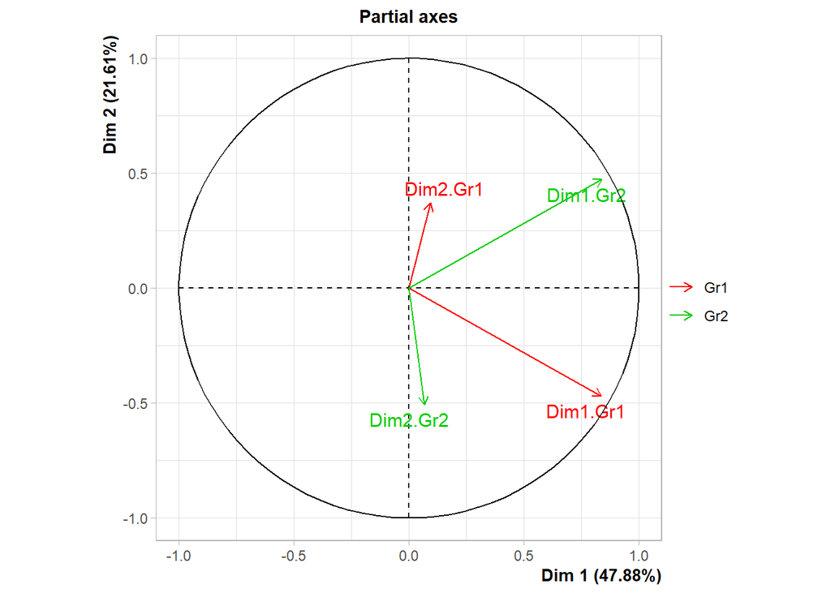

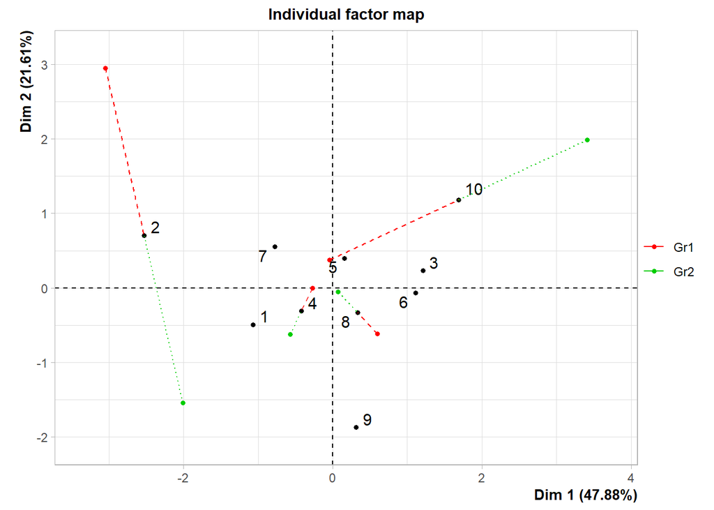

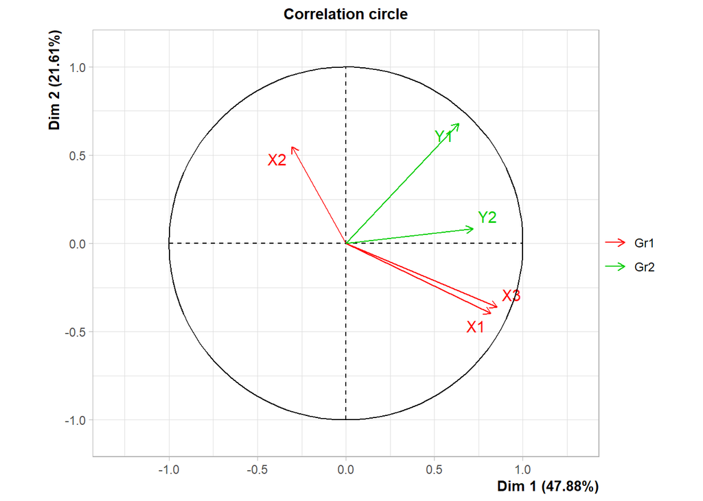

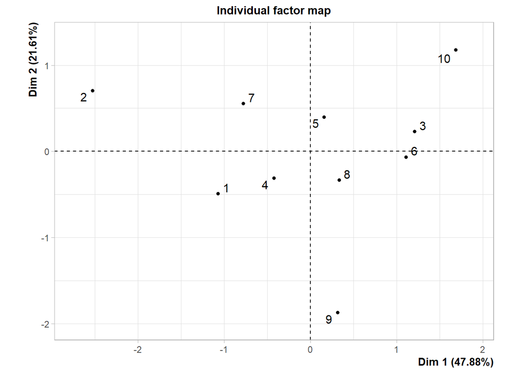

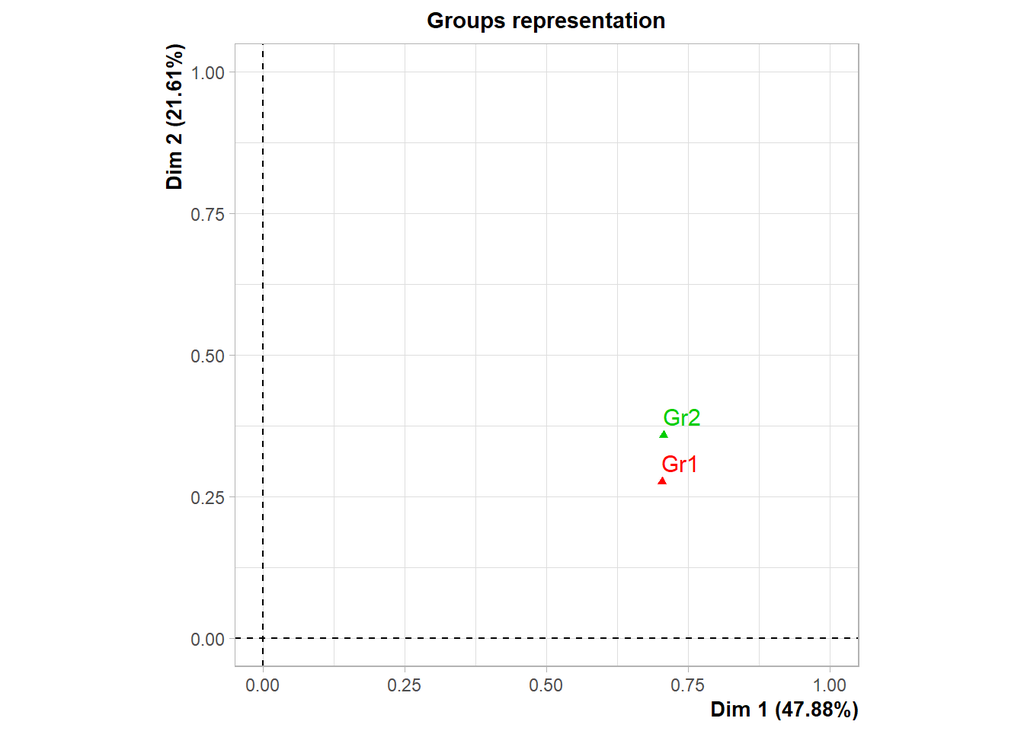

```r
library(FactoMineR)
library(factoextra)
Z.mfa<-MFA(dades,group=c(3,2),type=c('s','s'))
```

```r
summary(Z.mfa)
```

```
##
## Call:
## MFA(base = dades, group = c(3, 2), type = c("s", "s"))
##
##
## Eigenvalues
##                        Dim.1   Dim.2   Dim.3   Dim.4   Dim.5
## Variance               1.410   0.636   0.515   0.383   0.000
## % of var.             47.880  21.610  17.493  13.014   0.003
## Cumulative % of var.  47.880  69.490  86.983  99.997 100.000
##
## Groups
##        Dim.1    ctr   cos2    Dim.2    ctr   cos2    Dim.3    ctr   cos2
## Gr1 |  0.703 49.901  0.423 |  0.277 43.555  0.066 |  0.091 17.697  0.007 |
## Gr2 |  0.706 50.099  0.389 |  0.359 56.445  0.101 |  0.424 82.303  0.140 |
##
## Individuals
##        Dim.1    ctr   cos2    Dim.2    ctr   cos2    Dim.3    ctr   cos2
## 1   | -1.073  8.173  0.430 | -0.491  3.781  0.090 | -0.750 10.924  0.210 |
## 2   | -2.530 45.402  0.882 |  0.705  7.814  0.069 | -0.146  0.413  0.003 |
## 3   |  1.207 10.335  0.604 |  0.231  0.837  0.022 |  0.739 10.607  0.226 |
## 4   | -0.423  1.269  0.537 | -0.311  1.524  0.291 | -0.098  0.186  0.029 |
## 5   |  0.159  0.179  0.017 |  0.399  2.507  0.108 |  0.566  6.222  0.217 |
## 6   |  1.109  8.730  0.429 | -0.065  0.067  0.001 |  0.888 15.320  0.275 |
## 7   | -0.779  4.307  0.387 |  0.556  4.856  0.197 |  0.681  9.015  0.296 |
## 8   |  0.332  0.784  0.477 | -0.332  1.734  0.476 |  0.037  0.027  0.006 |
## 9   |  0.314  0.697  0.024 | -1.871 55.025  0.870 | -0.414  3.321  0.042 |
## 10  |  1.684 20.124  0.430 |  1.179 21.856  0.211 | -1.505 43.966  0.344 |
##
## Continuous variables
##        Dim.1    ctr   cos2    Dim.2    ctr   cos2    Dim.3    ctr   cos2
## X1  |  0.819 22.395  0.670 | -0.397 11.673  0.158 |  0.308  8.698  0.095 |
## X2  | -0.306  3.131  0.094 |  0.548 22.212  0.300 |  0.029  0.075  0.001 |
## X3  |  0.854 24.374  0.730 | -0.361  9.670  0.131 |  0.312  8.924  0.098 |
## Y1  |  0.638 22.090  0.407 |  0.680 55.620  0.462 |  0.283 11.873  0.080 |
## Y2  |  0.718 28.010  0.516 |  0.083  0.826  0.007 | -0.688 70.429  0.474 |
```

```r
summary(Z.mfa$separate.analyses$Gr1)
```

```
##
## Call:
## PCA(X = aux.base, scale.unit = TRUE, ncp = ncp, ind.sup = ind.sup,
##      row.w = row.w, col.w = weight.col.mfa[(ind.grpe + 1):(ind.grpe +
##          group[g])], graph = FALSE)
##
##
## Eigenvalues
##                        Dim.1   Dim.2   Dim.3
## Variance               2.123   0.874   0.003
## % of var.             70.774  29.130   0.096
## Cumulative % of var.  70.774  99.904 100.000
##
## Individuals
##        Dist    Dim.1    ctr   cos2    Dim.2    ctr   cos2    Dim.3    ctr
## 1  |  2.029 | -1.209  6.888  0.355 | -1.629 30.375  0.645 | -0.001  0.003
## 2  |  3.332 | -3.214 48.652  0.930 |  0.879  8.840  0.070 | -0.042  6.033
## 3  |  1.464 |  1.389  9.082  0.900 | -0.458  2.401  0.098 |  0.073 18.587
## 4  |  0.548 | -0.249  0.293  0.207 | -0.488  2.720  0.791 | -0.029  2.849
## 5  |  1.036 |  0.023  0.002  0.000 | -1.035 12.252  0.998 |  0.034  3.982
## 6  |  2.361 |  1.809 15.413  0.587 |  1.517 26.339  0.413 | -0.002  0.019
## 7  |  1.258 | -0.837  3.299  0.443 |  0.939 10.087  0.557 |  0.024  1.993
## 8  |  0.681 |  0.635  1.899  0.870 | -0.246  0.690  0.130 | -0.001  0.002
## 9  |  1.765 |  1.750 14.429  0.983 | -0.195  0.436  0.012 | -0.122 51.709
## 10 |  0.725 | -0.096  0.043  0.017 |  0.716  5.859  0.974 |  0.065 14.824
##      cos2
## 1   0.000 |
## 2   0.000 |
## 3   0.002 |
## 4   0.003 |
## 5   0.001 |
## 6   0.000 |
## 7   0.000 |
## 8   0.000 |
## 9   0.005 |
## 10  0.008 |
##
## Variables
##       Dim.1    ctr   cos2    Dim.2    ctr   cos2    Dim.3    ctr   cos2
## X1 |  0.971 44.433  0.943 |  0.235  6.313  0.055 | -0.038 49.254  0.001 |
## X2 | -0.465 10.183  0.216 |  0.885 89.687  0.784 |  0.002  0.129  0.000 |
## X3 |  0.982 45.383  0.964 |  0.187  4.000  0.035 |  0.038 50.617  0.001 |
```

```r
summary(Z.mfa$separate.analyses$Gr2)
```

```
##
## Call:
## PCA(X = aux.base, scale.unit = TRUE, ncp = ncp, ind.sup = ind.sup,
##      row.w = row.w, col.w = weight.col.mfa[(ind.grpe + 1):(ind.grpe +
##          group[g])], graph = FALSE)
##
##
## Eigenvalues
##                        Dim.1   Dim.2
## Variance               1.306   0.694
## % of var.             65.301  34.699
## Cumulative % of var.  65.301 100.000
##
## Individuals
##        Dist    Dim.1    ctr   cos2    Dim.2    ctr   cos2
## 1  |  0.982 | -0.738  4.173  0.565 |  0.648  6.045  0.435 |
## 2  |  1.625 | -1.617 20.020  0.990 | -0.166  0.395  0.010 |
## 3  |  1.354 |  0.948  6.883  0.490 | -0.967 13.479  0.510 |
## 4  |  0.500 | -0.471  1.702  0.889 |  0.166  0.399  0.111 |
## 5  |  1.128 |  0.359  0.989  0.101 | -1.070 16.484  0.899 |
## 6  |  0.563 |  0.323  0.798  0.329 | -0.461  3.062  0.671 |
## 7  |  1.038 | -0.608  2.835  0.344 | -0.840 10.178  0.656 |
## 8  |  0.133 |  0.047  0.017  0.127 |  0.124  0.222  0.873 |
## 9  |  1.828 | -0.942  6.793  0.266 |  1.566 35.350  0.734 |
## 10 |  2.878 |  2.699 55.791  0.879 |  0.999 14.386  0.121 |
##
## Variables
##       Dim.1    ctr   cos2    Dim.2    ctr   cos2
## Y1 |  0.808 50.000  0.653 | -0.589 50.000  0.347 |
## Y2 |  0.808 50.000  0.653 |  0.589 50.000  0.347 |
```

Comparem

- Comparem la distribució de la varibilitat

```r
summary(Z.pca)$sdev^2
```

```
## [1] 1.4097325312 0.6362514517 0.5150580157 0.3831600656 0.0001021409
```

```r
Z.mfa$eig[,1]
```

```
##       comp 1       comp 2       comp 3       comp 4       comp 5
## 1.4097325312 0.6362514517 0.5150580157 0.3831600656 0.0001021409
```

Comprovem ara les components principals

```r
mat<-Z.pca$rotation
sweep(mat, 2, mat[1, ], "/")
```

```
##           PC1        PC2         PC3        PC4          PC5
## X1  1.0000000  1.0000000  1.00000000  1.0000000  1.000000000
## X2 -0.3739310 -1.3794670  0.09301927  2.8083598 -0.059203692
## X3  1.0432386  0.9101782  1.01293364  0.7406477 -1.041575266
## Y1  0.9931551 -2.1828762  1.16837361 -1.0418127  0.060778976
## Y2  1.1183424 -0.2659506 -2.84557288  0.2791115  0.003675479
```

```r
mat2<-Z.mfa$global.pca$var$coord
sweep(mat2, 2, mat2[1, ], "/")
```

```
##         Dim.1      Dim.2       Dim.3      Dim.4       Dim.5
## X1  1.0000000  1.0000000  1.00000000  1.0000000  1.00000000
## X2 -0.3739310 -1.3794670  0.09301927  2.8083598 -0.05920369
## X3  1.0432386  0.9101782  1.01293364  0.7406477 -1.04157527
## Y1  0.7789238 -1.7120128  0.91634632 -0.8170856  0.04766848
## Y2  0.8771072 -0.2085830 -2.23176064  0.2189049  0.00288265
```

- Finalment comparem les gràfiques dels individus

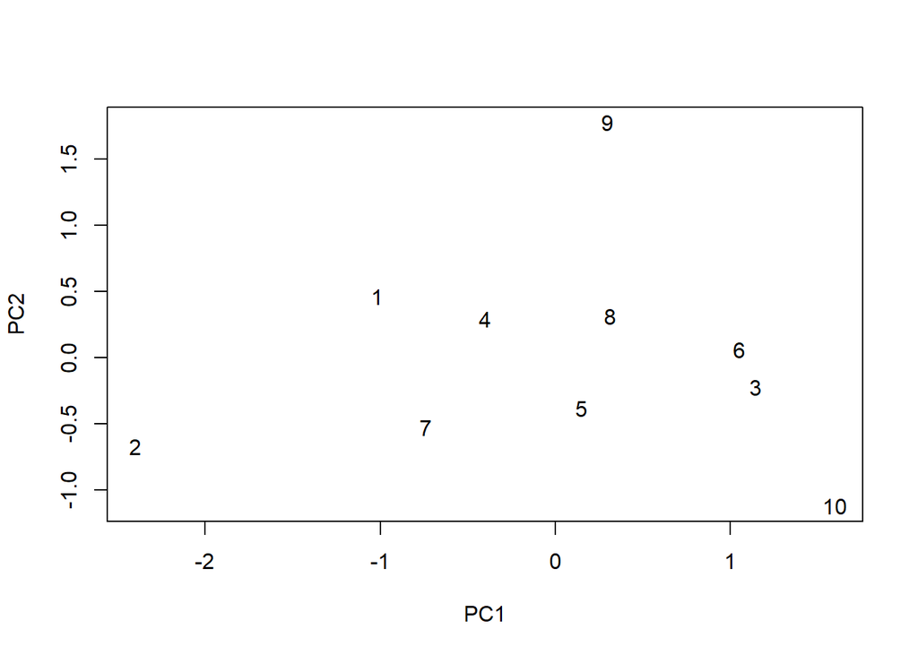

```r
plot(Z.pca$x[,1],Z.pca$x[,2],type='n',xlab='PC1',ylab='PC2')
text(Z.pca$x[,1],Z.pca$x[,2],label=1:n)
```

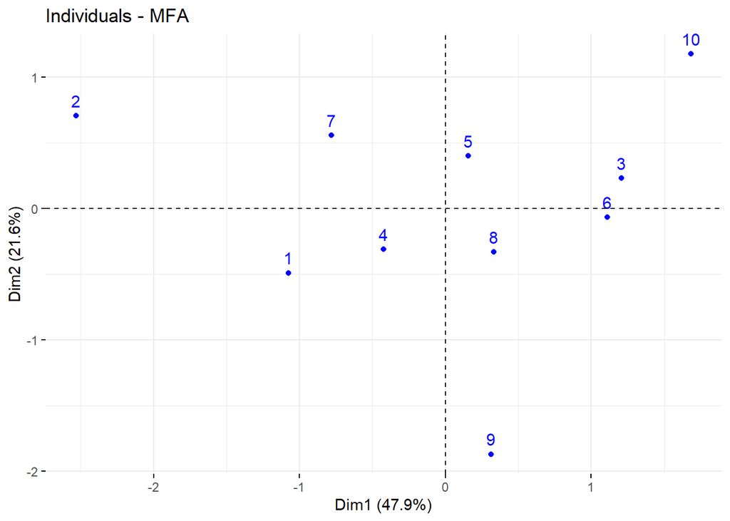

```r
fviz_mfa_ind(Z.mfa)
```

Comprovem que els resultats són equivalents.